# CS100 Studio 3

Hypothesis 4

```r
change_vs_age <- responses %>%
                select(Age, Changing.the.past) %>%
                na.omit() %>%
                group_by(Age) %>%
                summarise(avg_past = mean(Changing.the.past))
```

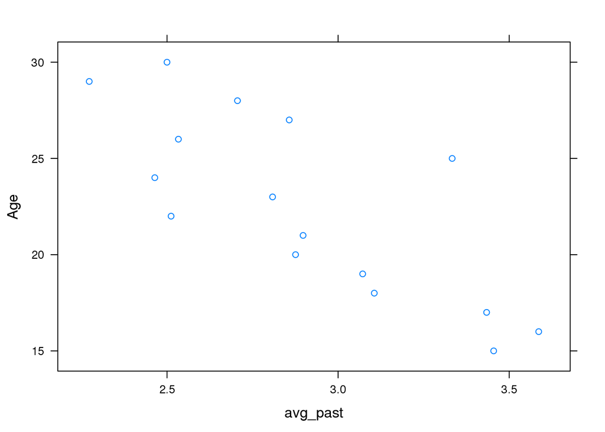

```r
xyplot( Age ~ avg_past, data = change_vs_age, main="")
```

From the scatter plot, we can see that there is fairly evident trend that older respondants to the survey don’t really have any desire to change things in the past because of things they may hav done, whereas younger folks seem to want to change some past actions. This is in line with what we may hypothesize because older people tend to have less (impulsive) regret

Hypothesis 5

```r
online_vs_passive_sport <- responses %>%
  select(Internet.usage, Passive.sport)
```

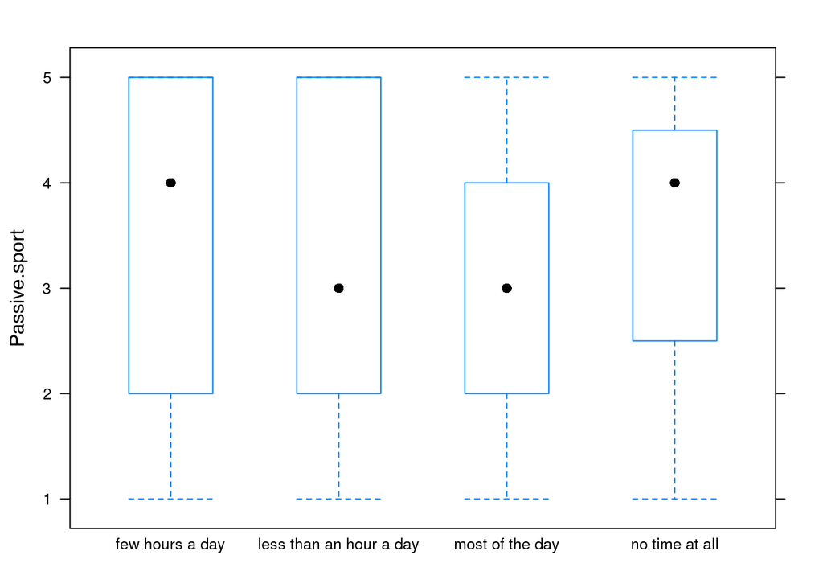

```r
bwplot( Passive.sport ~ Internet.usage, data = online_vs_passive_sport, main="")
```

Using a box and whisker plot is best because of the fact that internet usage is categorical data. We observe that, on average, there is not as definitive a relationship between spending time online and interest in sports for leisure. Those who spend a few hours a day online seem to be about as interested in sports as those who spend no time at all online. Meanwhile, those who spend most of the day online are comparable to those who spend less than an hour a day, a fact that we might not have expected previously. Based on the responses, the correlation does not seem to exist

Hypothesis 6

```r
young_vs_money <- responses %>%
  select(Age, Finances) %>%
  filter(Age < 24)
```

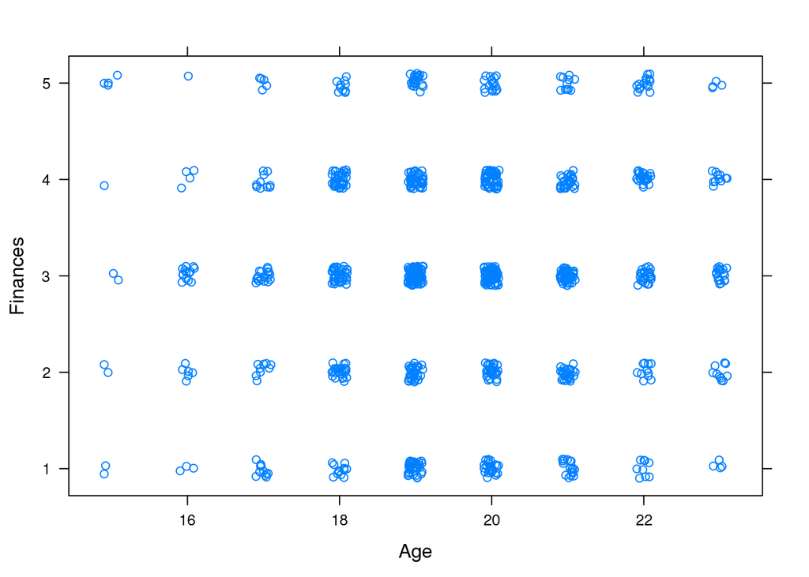

```r
xyplot( Finances ~ Age, data = young_vs_money, main="", jitter.x=TRUE, jitter.y=TRUE)
```

A jitter plot was used here and from it, we don’t really see much of a correlation between young people and saving their money. It seems like for each age group, the responses were generally right in the middle of saving their money a lot, which implies that those people neither spend all their money nor save it. There does not seem to be a lot of saving going on, nor is there an exorbitant amount of spending across the board.